# User guide for executing `CytOpT` on `HIPC` data

Paul Freulon, Jérémie Bigot, Kalidou BA, Boris Hejblum

2025-04-01

# Introduction

`CytOpT` is a supervised method that directly estimates the cell proportions in a flow-cytometry data set by using a source gating as its input and relies on regularized optimal transport.

# Analysis of HIPC data

As an illustrative example, we analyze here the flow cytometry data from the T-cell panel of the Human Immunology Project Consortium (HIPC) publicly available on ImmuneSpace [Gottardo et al. [2014]](https://www.nature.com/articles/nbt.2777).

An `HIPC` data set has the following structure (split into 2 files):

- `xx_y_values`: flow-cytometry measurements
- `xx_y_clust`: file with the corresponding manual clustering

Above, `xx` denotes the center where the data analysis was performed, and `y` denotes the patient and the replicate of the biological sample in question.

## Data load

```r
library(CytOpT)
data("HIPC_Stanford")
```

Here are the first few lines of the flow-cytometry measurements from patient *1228* replicate *1A*:

| CCR7 | CD4 | CD45RA | CD3 | HLADR | CD38 | CD8 |
| --- | --- | --- | --- | --- | --- | --- |
| 717.3339 | 1146.5768 | 3094.811 | 2526.265 | 1333.1118 | 1510.164 | 3203.711 |
| 681.8582 | 1398.1466 | 3168.901 | 2394.297 | 918.4464 | 1306.356 | 3056.621 |
| 402.3024 | 920.2601 | 3440.265 | 2221.533 | 1585.4507 | 1086.020 | 2728.252 |
| 1509.6527 | 1492.2483 | 3143.388 | 2592.564 | 1116.4272 | 1577.515 | 3191.382 |
| 1365.9507 | 659.6762 | 3382.406 | 2126.847 | 1317.9880 | 1277.266 | 3079.729 |
| 1388.9562 | 1213.0846 | 3486.772 | 2450.046 | 1103.4678 | 1474.890 | 3200.576 |

The manual clustering of these data into 10 cell populations (CD8 Effector, CD8 Naive, CD8 Central Memory, CD8 Effector Memory, CD8 Activated, CD4 Effector, CD4 Naive, CD4 Central Memory, CD4 Effector Memory, CD4 Activated) can be accessed from the `HIPC_Stanford_1228_1A_labels` object.

We will use the manual gating from patient *1228* replicate *1A* as our source proportions to infer proportions for patient *1369* replicate *1A*.

## Computation of the benchmark class proportions for target data

Because in this example, we know the true proportions in the target data set `HIPC_Stanford_1369_1A`, we can assess the gap between the estimate form `CytOpt` and the cellular proportions from the reference manual gating. For this purpose, we compute those manual proportions with:

```r
gold_standard_manual_prop <- c(table(HIPC_Stanford_1369_1A_labels) /
                                 length(HIPC_Stanford_1369_1A_labels))
```

## `CytOpT`

### Optimization

```r
set.seed(123)
res <- CytOpT(X_s = HIPC_Stanford_1228_1A, X_t = HIPC_Stanford_1369_1A,
              Lab_source = HIPC_Stanford_1228_1A_labels,
              theta_true = gold_standard_manual_prop,
              method="minmax", monitoring = TRUE)
```

```
#> Converting `X_s` from data.frame to matrix type
#> Converting `X_t` from data.frame to matrix type
#> Running MinMax optimization...
#> Done in 7.2 secs
```

### Results

```r
summary(res)
```

```
#> Estimation of cell proportions with MinMax swapping from CytOpt:
#>                     Gold_standard       MinMax
#> CD8 Effector          0.017004001 4.432901e-02
#> CD8 Naive             0.128736173 1.007199e-01
#> CD8 Central Memory    0.048481996 3.892319e-02
#> CD8 Effector Memory   0.057484114 6.968146e-02
#> CD8 Activated         0.009090374 7.936863e-03
#> CD4 Effector          0.002324076 2.475853e-05
#> CD4 Naive             0.331460344 3.598396e-01
#> CD4 Central Memory    0.281713344 1.922294e-01
#> CD4 Effector Memory   0.102082843 1.682680e-01
#> CD4 Activated         0.021622735 1.804780e-02
#>
#> Final Kullback-Leibler divergences:
#> MinMax swapping
#>      0.05835319
#> Number of iterations:
#> MinMax swapping
#>           10000
```

Some visualizations are provided by the `plot()` method:

```
#> Plotting KL divergence for iterations 10 to 1000 while there were at least 10000 iterations performed for each method.
```

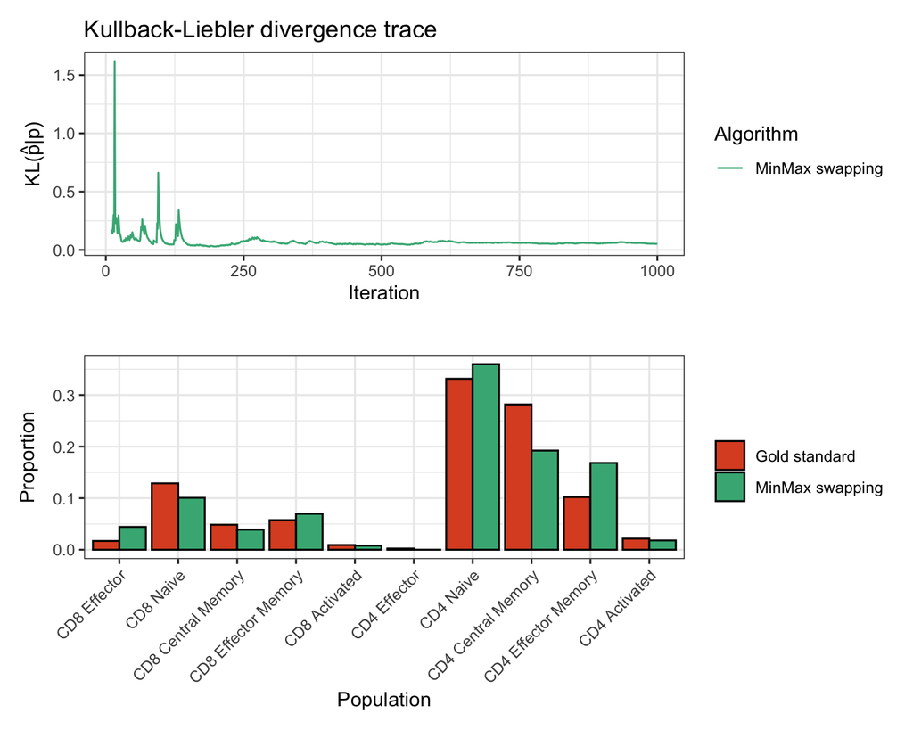

```r
plot(res)
```

### Performance evaluation

Concordance between the manual gating gold-standard and `CytOpt` estimation can be graphically diagnosed with Bland-Altman plots:

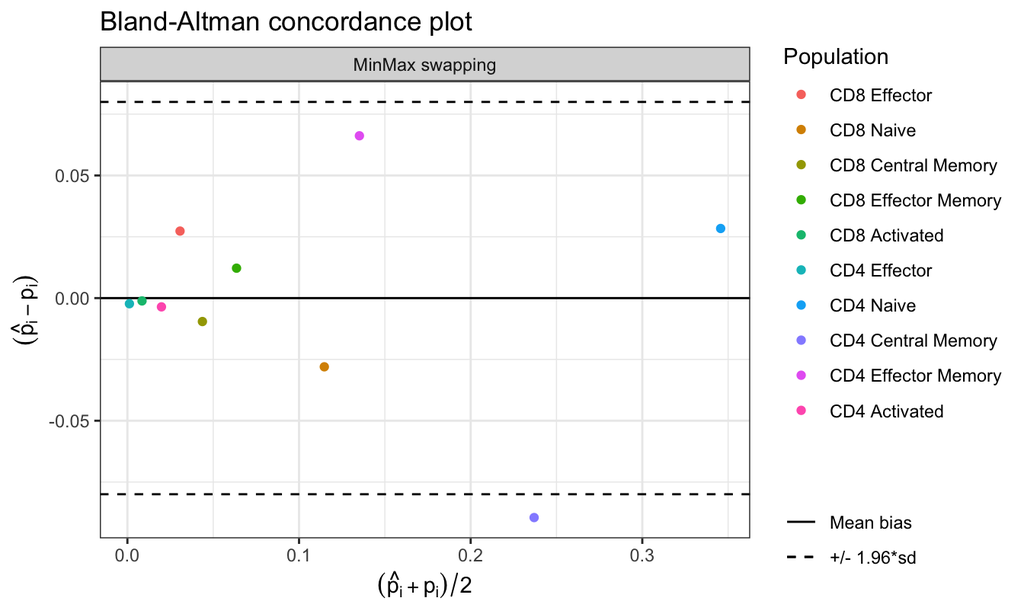

```r
Bland_Altman(res$proportions)
```

The methods implemented in the `CytOpt` package are detailed in the following article:

> Paul Freulon, Jérémie Bigot, Boris P. Hejblum. CytOpT: Optimal Transport with Domain Adaptation for Interpreting Flow Cytometry data *Annals of Applied Statistics*, *17*(2), 1086-1104. doi:10.1214/22-AOAS1660 https://doi.org/10.1214/22-AOAS1660 https://arxiv.org/abs/2006.09003